# Gotta Class 'em All!

## Predicting Pokémon Types with Classification Algorithms

### A data science tutorial by Dionel Olo

## Why study data science?

Scientists collect and analyze decades of data in order to seek out trends or search for correlations. Businesses look at previous customers, trying to predict how best to attract the next ones. Non-profit organizations study the patterns of their previous donators in order to find their most engaged members, and ask them to upgrade or renew their memberships. And sometimes, curious people with a lot of time on their hands just want to find out the answer to an interesting question. All of these are just a few examples of data science, the practice of gathering, processing, and analyzing data in order to see patterns or gain insight on a real-world problem. This webpage will provide an example of a data science study, in which we will use a classification algorithm to sort data into categories.

For our example, we'll be looking at data from the *Pokémon* video games. Each of the nearly 900 species of Pokémon has up to two types, up to three abilities, a pool of possible moves, and six base stats: HP, Attack, Defense, Special Attack, Special Defense, and Speed. The eighteen types of Pokemon battle each other based on weaknesses and resistances, and their base stats intuitively match their natures. For example, Rock-type Pokémon tend to be defensive and slow, while Electric type Pokémon tend to be fast and frail. But how well does this pattern hold up? How accurately can we predict the type of a Pokémon from its stats? This is the question that we seek to answer using data science. Although any Pokémon player can check the type in-game, and probably knows types better than stats, our question isn't based on a necessity to predict the type. Instead, we are looking to see if a pattern exists.

## Collecting our data

The data science pipeline is a process which takes raw data and returns some insight on the real-world process which the data describes. This process begins with collecting the data. This step can involve taking measurements, conducting surveys, reading archives, or many other methods to gather information about some topic. For our example, we will be taking the data from [Bulbapedia](https://bulbapedia.bulbagarden.net/wiki/Main_Page), an online wiki which claims to be "one of the largest Pokémon resources on the internet." Bulbapedia hosts dozens of lists, sorting all Pokémon species by various categories; we are interested in the lists of Pokémon by base stats and by [National Pokédex number](https://bulbapedia.bulbagarden.net/wiki/List_of_Pok%C3%A9mon_by_National_Pok%C3%A9dex_number), which includes their types.

Our first step is to import and install all the modules we need for our project.

```python
# These modules are necessary for our project.
import requests as rq # Requests allows us to make an HTTP request to a URL.
from bs4 import BeautifulSoup # Beautiful Soup 4 provides us with tools to scrape data from the webpage.
import pandas as pd # pandas is a library which lets us store data in dataframes, and operate on that data.
!pip3 install lxml # lxml is required for pandas to read HTML into a dataframe. It must be installed,
# rather than imported.
import numpy as np # numpy lets us perform advanced mathematical operations.
from matplotlib import pyplot as plt # This gives our plots additional functionality.
from sklearn import svm # scikit-learn provides machine learning algorithms...
from sklearn.model_selection import train_test_split, cross_val_score # as well as tools for their use.
from sklearn.preprocessing import StandardScaler
```

On Bulbapedia, the lists of Pokémon are stored in HTML tables. These tables list every Pokémon, and when appropriate, each form of that Pokémon.

[figure not shown]

Figure 1: The first six entries on Bulbapedia's list of Pokémon by base stats.

Here, we can see the Pokémon listed by National Pokédex number, followed by an in-game sprite, the Pokémon's name, its six stats, its base stat total (BST), and the average of its stats. We also see an example of a form being listed separately; because Mega Evolution increases a Pokémon's BST by 100 by increasing its most important stats, Mega Venusaur is listed alongside Venusaur.

Our current goal is to parse this table into a form which we can analyze: a *pandas* dataframe.

```python
# We make an HTTP request from the Bulbapedia URL.
page = rq.get('https://bulbapedia.bulbagarden.net/wiki/List_of_Pok%C3%A9mon_by_base_stats_(Generation_VIII-present)')

# With this page, we can get its HTML, and parse it into a BeautifulSoup 4 object.
soup = BeautifulSoup(page.text)

# Now, we can find the table using BeautifulSoup.
table = soup.find('table') # This will get the first table on the webpage.

# And now, we can parse that table using pandas. We provide it with the raw HTML text.
df_stats = pd.read_html(str(table))[0] # Pandas reads all tables into a dataframe, but we only need one.
df_stats.head() # Now we can display the first five rows of the dataframe.
```

|  | 0 |
| --- | --- |
| 0 | ShortcutsLPBBS |

This dataframe clearly doesn't match the Bulbapedia table. What went wrong? Using the Inspect Element tool, we can see the problem.

[figure not shown]

Figure 2: The first table on the Bulbapedia page, and the corresponding HTML tag.

We've parsed the wrong table. Instead of the table of Pokémon, we parsed a smaller table which the wiki uses to hold redirects. The table we want is actually the second table on the page.

```python
tables = soup.findAll('table') # This will get all the tables from the HTML.
df_stats = pd.read_html(str(tables))[1] # Here, pandas creating a list of tables works to our advantage.
# We can get the table that we need out of the list.
df_stats.head()
```

|  | # | Unnamed: 1 | Pokémon | HP | Attack | Defense | Sp. Attack | Sp. Defense | Speed | Total | Average |
| --- | --- | --- | --- | --- | --- | --- | --- | --- | --- | --- | --- |
| 0 | 1 | NaN | Bulbasaur | 45 | 49 | 49 | 65 | 65 | 45 | 318 | 53.00 |
| 1 | 2 | NaN | Ivysaur | 60 | 62 | 63 | 80 | 80 | 60 | 405 | 67.50 |
| 2 | 3 | NaN | Venusaur | 80 | 82 | 83 | 100 | 100 | 80 | 525 | 87.50 |
| 3 | 3 | NaN | Venusaur (Mega Venusaur) | 80 | 100 | 123 | 122 | 120 | 80 | 625 | 104.17 |
| 4 | 4 | NaN | Charmander | 39 | 52 | 43 | 60 | 50 | 65 | 309 | 51.50 |

We also need to get each Pokemon's type into a dataframe. The page which lists them contains eight tables, one for each generation of main series games.

```python
page = rq.get('https://bulbapedia.bulbagarden.net/wiki/List_of_Pok%C3%A9mon_by_National_Pok%C3%A9dex_number')
soup = BeautifulSoup(page.text)
table = soup.findAll('table')

# We start with an empty dataframe which contains all the columns common to the eight tables.
df_types = pd.DataFrame(columns=['Ndex', 'MS', 'Pokémon', 'Type', 'Type.1'])
for index in range(1,9): # For each table, read it into a temporary dataframe and append it to the main dataframe.
    df_temp = pd.read_html(str(table))[index]
    df_types = df_types.append(df_temp.iloc[:,1:], ignore_index = True)
df_types.head()
```

|  | Ndex | MS | Pokémon | Type | Type.1 |
| --- | --- | --- | --- | --- | --- |
| 0 | #001 | NaN | Bulbasaur | Grass | Poison |
| 1 | #002 | NaN | Ivysaur | Grass | Poison |
| 2 | #003 | NaN | Venusaur | Grass | Poison |
| 3 | #004 | NaN | Charmander | Fire | Fire |
| 4 | #005 | NaN | Charmeleon | Fire | Fire |

## Data cleanup

We've collected all the data that we need, but it's currently in two separate tables. We need to merge them.

```python
# Each Pokémon has a unique number in the National Pokédex, which is included in both charts.
# For this study, we will not be considering alternate forms. Dropping duplicate Pokédex numbers helps us both to
# merge the tables, and removes alternate forms.
df_stats = df_stats.drop_duplicates(subset='#', ignore_index = True)
df_types = df_types.drop_duplicates(subset='Ndex', ignore_index = True)
```

We also need to melt together the types, so a Pokemon with two types will be counted for both. For example, Bulbasaur will have an entry listing it as a Grass type, and a second entry listing it as a Poison type. This will help us look at all Pokémon of a certain type, without relying on the arbitrary type ordering used by the games. One example of this is the Steel/Flying Skarmory and the Flying/Steel Corviknight. Both of these Pokémon are birds known for their high defenses. Under this model, they would be treated as having the same type, and contributing to the averages and data for both Steel and Flying-type Pokémon.

```python
df_types = df_types.melt(id_vars=['Ndex','Pokémon'], value_vars=['Type','Type.1'])
df_types.sort_values(by=['Ndex']).head()
```

|  | Ndex | Pokémon | variable | value |
| --- | --- | --- | --- | --- |
| 0 | #001 | Bulbasaur | Type | Grass |
| 898 | #001 | Bulbasaur | Type.1 | Poison |
| 1 | #002 | Ivysaur | Type | Grass |
| 899 | #002 | Ivysaur | Type.1 | Poison |
| 2 | #003 | Venusaur | Type | Grass |

If there are no duplicate Pokédex numbers, then there are no duplicate Pokémon in the list, so now we can merge on the names of the Pokémon.

```python
df = pd.merge(df_types, df_stats, on = 'Pokémon')
df.head()
```

|  | Ndex | Pokémon | variable | value | # | Unnamed: 1 | HP | Attack | Defense | Sp. Attack | Sp. Defense | Speed | Total | Average |
| --- | --- | --- | --- | --- | --- | --- | --- | --- | --- | --- | --- | --- | --- | --- |
| 0 | #001 | Bulbasaur | Type | Grass | 1 | NaN | 45 | 49 | 49 | 65 | 65 | 45 | 318 | 53.0 |
| 1 | #001 | Bulbasaur | Type.1 | Poison | 1 | NaN | 45 | 49 | 49 | 65 | 65 | 45 | 318 | 53.0 |
| 2 | #002 | Ivysaur | Type | Grass | 2 | NaN | 60 | 62 | 63 | 80 | 80 | 60 | 405 | 67.5 |
| 3 | #002 | Ivysaur | Type.1 | Poison | 2 | NaN | 60 | 62 | 63 | 80 | 80 | 60 | 405 | 67.5 |
| 4 | #003 | Venusaur | Type | Grass | 3 | NaN | 80 | 82 | 83 | 100 | 100 | 80 | 525 | 87.5 |

Now, we can drop un-needed columns, such as the columns that only contained images on Bulbapedia, and the average stats.

```python
df = df.drop(columns = ['variable','#','Unnamed: 1', 'Average'])
df = df.rename(columns={'value':'Type'}) # We also rename the unclear 'value' column to Type.
```

Our next step is to remove duplicate types, so that single-type Pokémon are not listed with duplicate entries. For example, Charmander is listed twice as having the Fire type. This will affect further analysis: measures of central tendency will be skewed by the duplicate appearances of a single-typed Pokémon. Dual-type Pokémon are intended to appear twice, but will only appear in each type once.

```python
df = df.drop_duplicates(subset=['Pokémon','Type'])
df.head(10) # Increased head size to see that Charmander is listed only once.
```

|  | Ndex | Pokémon | Type | HP | Attack | Defense | Sp. Attack | Sp. Defense | Speed | Total |
| --- | --- | --- | --- | --- | --- | --- | --- | --- | --- | --- |
| 0 | #001 | Bulbasaur | Grass | 45 | 49 | 49 | 65 | 65 | 45 | 318 |
| 1 | #001 | Bulbasaur | Poison | 45 | 49 | 49 | 65 | 65 | 45 | 318 |
| 2 | #002 | Ivysaur | Grass | 60 | 62 | 63 | 80 | 80 | 60 | 405 |
| 3 | #002 | Ivysaur | Poison | 60 | 62 | 63 | 80 | 80 | 60 | 405 |
| 4 | #003 | Venusaur | Grass | 80 | 82 | 83 | 100 | 100 | 80 | 525 |
| 5 | #003 | Venusaur | Poison | 80 | 82 | 83 | 100 | 100 | 80 | 525 |
| 6 | #004 | Charmander | Fire | 39 | 52 | 43 | 60 | 50 | 65 | 309 |
| 8 | #005 | Charmeleon | Fire | 58 | 64 | 58 | 80 | 65 | 80 | 405 |
| 10 | #006 | Charizard | Fire | 78 | 84 | 78 | 109 | 85 | 100 | 534 |
| 11 | #006 | Charizard | Flying | 78 | 84 | 78 | 109 | 85 | 100 | 534 |

Now, our dataframe contains only the data that we need. Pokemon are listed for each type they have, and duplicates have been removed.

## Exploratory Data Analysis

The next part of the data science process is exploring the data, looking for initial patterns. Here, we want to see if a correlation exists between stats and type. Pandas comes with several types of plotting functions. Here, we will be grouping together all Pokémon by type, and creating box plots of their base stat total. We want to see if some types tend to have higher BSTs than others.

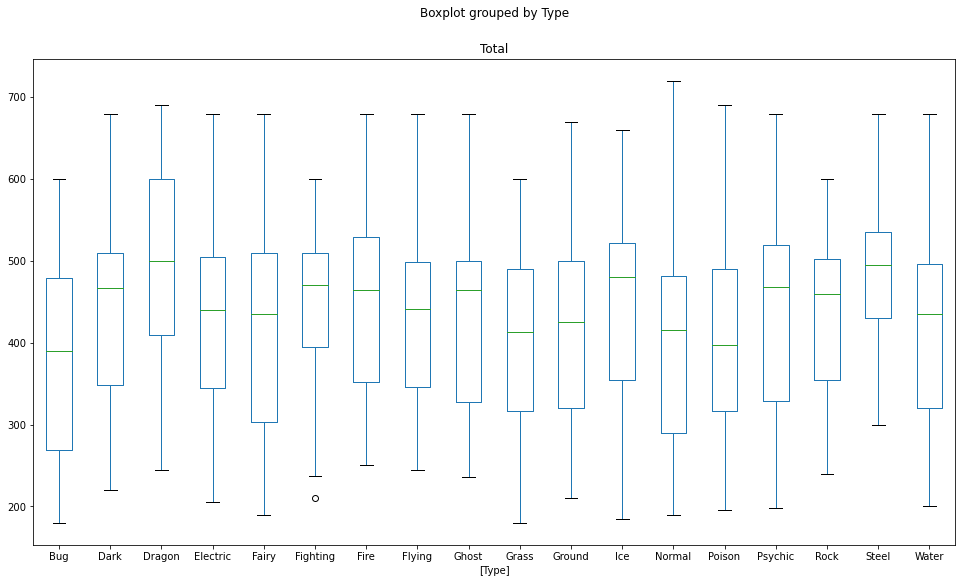

```python
df.boxplot(column='Total', by=['Type'], figsize = (16,9), grid = False)
```

Here, we can see that some types tend to have a higher BST than others. Bug type Pokémon, on average, are the weakest, with a mean BST of under 400. Dragon type Pokémon are the strongest, with a mean BST of approximately 500. There is only one outlier: by looking at the BSTs of Fighting-type Pokémon, we can determine that this must be Tyrogue, a weak pre-evolution.

We can see that there is some correlation between type and statistics. But what about for the individual stats? Gamers know that intuitively, a Pikachu can run circles around a Geodude, but how well does this hold up numerically? We can use another box plot to find out how types correspond with base speed.

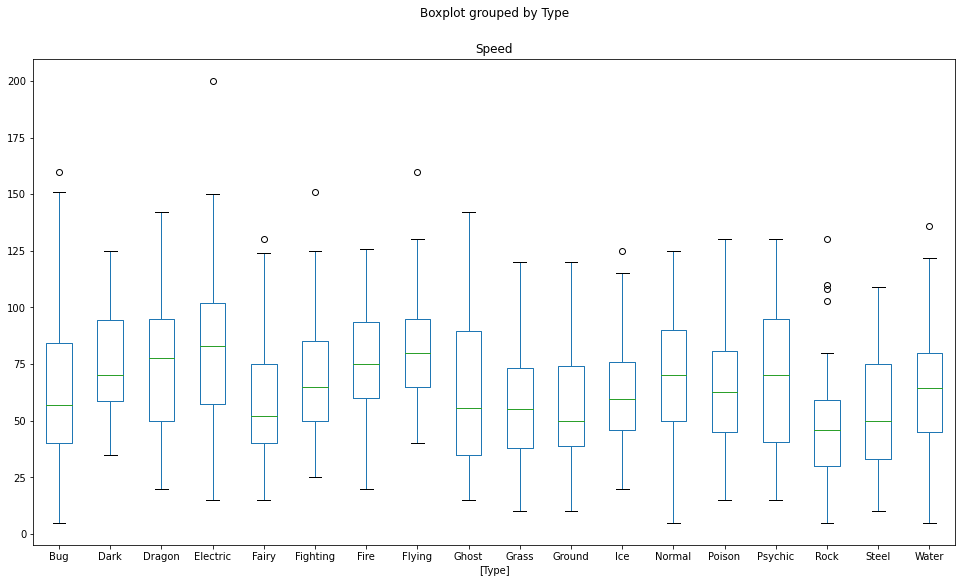

```python
df.boxplot(column='Speed', by=['Type'], figsize = (16,9), grid = False)
```

Another question that comes to mind is "How strongly are two base stats correlated"? If these correlations vary between types, then there is evidence that stats are a viable predictor of type. To continue with our examples of Rock and Electric type Pokémon, we will plot their speed against their defense on a scatter plot.

```
Electric: Defense = -0.037685 (Speed) + 66.243505
Rock: Defense = -0.639875 (Speed) + 136.808525
```

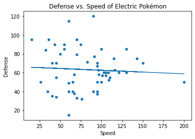

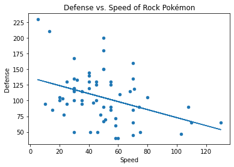

```python
# Create dataframes containing only Electric and Rock type Pokemon.
df_elec = df[df['Type'] == 'Electric']
df_rock = df[df['Type'] == 'Rock']

# Plot these onto a scatter plot
df_elec.plot.scatter(x='Speed', y='Defense', title='Defense vs. Speed of Electric Pokémon')

# We can use numpy to form a regression line, and see how the statistics trend.
m, b = np.polyfit(df_elec['Speed'], df_elec['Defense'], 1)
plt.plot(df_elec['Speed'], m * df_elec['Speed'] + b)
print("Electric: Defense = %2f (Speed) + %2f" % (m, b))

df_rock.plot.scatter(x='Speed', y='Defense', title='Defense vs. Speed of Rock Pokémon')
m, b = np.polyfit(df_rock['Speed'], df_rock['Defense'], 1)
plt.plot(df_rock['Speed'], m * df_rock['Speed'] + b)
print("Rock: Defense = %2f (Speed) + %2f" % (m, b))
```

## Machine Learning

We've mentioned a classification algorithm once at the start of this tutorial, but now is a great time to get into more detail, before implementing one of our own. Classification algorithms are a class of machine learning algorithm which take in predictor data and output the most likely class that the predictor data belongs to. For this study, the predictor data is the base stats of a Pokémon, and the class is the type. Essentially, the machine "learns" what type a Pokémon with certain stats has, and uses that knowledge to predict the rest.

We will be using scikit-learn's Linear SVM, a support vector machine. This machine works by calculating a hyperplane that divides the set of data based on categories. The support vectors the algorithm is named after are vectors between the hyperplane and its closest points. scikit-learn also provides other tools, such as a tool that generates training and test data.

```python
# Split the data into two halves, for training and for testing.
# Our predictors are the base stats of the Pokémon, and our target is the type.
df_stats_only = df[['HP','Attack','Defense','Sp. Attack','Sp. Defense','Speed','Total']]

# We preprocess the training data so the classification equation is solved faster.
scaler = StandardScaler()
scaler.fit(df_stats_only)

x_train, x_test, y_train, y_test = train_test_split(scaler.transform(df_stats_only), df[['Type']], test_size=0.5)
```

```python
# Create a linear SVM. We set the maximum iterations and tolerance to ensure convrgence.
linsvm = svm.LinearSVC(max_iter = 10000, tol=1e-6)
```

```python
# The values of types are in a column array, but the fit() function expects them in a row.
# We must reshape the array.We get the numpy array of values, then use ravel() to reshape it.
linsvm.fit(x_train, y_train.values.ravel())
```

```
LinearSVC(max_iter=10000, tol=1e-06)
```

Now, we can run a prediction on our test data, and compare it with our expected results.

```python
print(linsvm.predict(x_test)[0:5]) # Predictions using the algorithm
print(y_test.values.ravel()[0:5]) # Expected results
```

```
['Psychic' 'Normal' 'Psychic' 'Water' 'Psychic']
['Flying' 'Normal' 'Dark' 'Poison' 'Bug']
```

From these values, the algorithm seems to be inaccurate. But how accurate is the whole thing? We can find out using k-fold cross-validation. With this method, the data is partitioned into *k* slices, where *k* - 1 of them are training data, and the remaining slice is test data. The cross-validation function will return an array of *k* elements, scored as the percent of correct predictions. We can also show the mean and standard deviation of these guesses.

```python
# k-fold cross-validation with 10 partitions.
scores = cross_val_score(linsvm, scaler.transform(df_stats_only), df[['Type']].values.ravel(), cv = 10)
scores
```

```
array([0.19847328, 0.12977099, 0.15267176, 0.21538462, 0.15384615,
       0.11538462, 0.16923077, 0.16923077, 0.13846154, 0.12307692])
```

```python
print("The average accuracy of the SVM is %0.2f%%, with a standard deviation of %0.2f."
     % (scores.mean() * 100, scores.std()))
```

```
The average accuracy of the SVM is 15.66%, with a standard deviation of 0.03.
```

## Conclusion and Further Study

With this low of an accuracy, we can claim that the base stats of a Pokémon are not a strong predictor of its type. However, this is not necessarily bad. This helps make the gameplay less predictable; a Rock-type user can have Aerodactyl outspeed and land a powerful Earthquake on the fast Electric Pikachu. Fighting-type moves that make defensive Rock and Steel-types crumble do hardly anything to the just as defensive, Water/Poison Toxapex... who still doesn't look forward to Ground-type moves. If every Pokémon type had a clear stat spread, then it would have a clear competitive niche, and the metagame would base itself solely on building with and countering these archetypes. However, with the diversity of 898 species, there's plenty of room to build around your favorite Pokémon, or find the perfect cornerstone to your latest team.

There's more data science that can be done. For example, earlier we noted that Dragon-type Pokémon are, on average, stronger than Bug-type Pokémon. How much of that is because Bug-types are found much earlier in the game than Dragon-types? We could plot each Pokémon's BST against the route it is found on. This would require us to standardize route numbers across games, and collect data from multiple tables. By now, you've learned enough about the data science pipeline to plan out how you would do this project, or any other projects you feel motivated to do.

The world of data science, like the world of Pokémon, is a vast, wonderful, growing, and unpredictable world. With this tutorial, you've taken your first step into the tall grass, and are ready to be the very best data scientist!

## Additional Resources

Python

- [pandas documentation](https://pandas.pydata.org/docs/) Learn more about dataframes and manipulating them.
- [BeautifulSoup 4 documentation](https://www.crummy.com/software/BeautifulSoup/bs4/doc/) Learn more about reading and parsing HTML.
- [numpy documentation](https://numpy.org/doc/) Learn more about advanced mathematical operations.
- [scikit-learn documentation](https://scikit-learn.org/stable/) Learn more about machine learning.
- [Article on classification algorithms](https://stackabuse.com/overview-of-classification-methods-in-python-with-scikit-learn) Learn more about classification algorithms.

Pokémon

- [Bulbapedia's lists of Pokémon](https://bulbapedia.bulbagarden.net/wiki/List_of_Pok%C3%A9mon) Lists of Pokémon sorted by multiple different criteria.
- [Smogon stats](https://www.smogon.com/stats/) Data from the Pokémon Showdown battle simulator, focusing on commonly used Pokémon, items, and movesets in competitive play.